# R Notebook

Week 11 Day 3

### Lesson 1

## Clustering

Clustering is unsupervised

Data can be segmented, manually - groups can be split manually into groups, e.g.

age over 20 + has 4+ children, age under 20 + has <4 children

This can be easy for small datasets, but can quickly become complicated

This is clustering

Clustering algorithims - connectivity models - hierarchical clustering - centroid models - k means clustering - distribution models - density models

### Lesson 2

## Hierarchical Clustering

When there is an inherent hierarchy in the data

There are two ways to do hierarchical clustering; aggolomerative divsive

They both end up in a dendrogram.

```r
library(tidyverse)
library(cluster)
library(factoextra)
library(dendextend)
library(corrplot)
```

```r
edu_data <- read_csv("data/school_data.csv")
```

|  | home_school | state_school | urban_pop | private_school |
| --- | --- | --- | --- | --- |
| Alabama | 1320 | 23600 | 5800 | 2120 |
| Alaska | 1000 | 26300 | 4800 | 4450 |
| Arizona | 810 | 29400 | 8000 | 3100 |
| Arkansas | 880 | 19000 | 5000 | 1950 |
| California | 900 | 27600 | 9100 | 4060 |
| Colorado | 790 | 20400 | 7800 | 3870 |
| Connecticut | 330 | 11000 | 7700 | 1110 |
| Delaware | 590 | 23800 | 7200 | 1580 |
| Florida | 1540 | 33500 | 8000 | 3190 |
| Georgia | 1740 | 21100 | 6000 | 2580 |

[output cut: 40 more lines]

```r
# checking that the dataframe has been normalised

edu_data_scale %>%
  pivot_longer(cols = everything(),
               names_to = "type",
               values_to = "value") %>% #convert data to long format
  group_by(type) %>%
  summarise(mean = round(mean(value)),
            sd = sd(value))
```

[output not shown]

```r
# creating a correlation plot - like we did with the penguins

corrplot(cor(edu_data_scale), method = "number", type = "lower")
```

[output not shown]

Calculating the distances between variables

```r
diss_matrix <- edu_data_scale %>%
  select(home_school) %>%
  dist(method = "euclidean")
```

```r
# visualising the above matrix / distance calculations
fviz_dist(diss_matrix)
```

[output not shown]

building the dendrogram

```r
clusters <- diss_matrix %>%
  hclust(method = "complete")
```

Plotting the dendrogram

```r
clusters %>%
  plot(cex = 0.5, hang = -5)
```

[output not shown]

calculating alternative clusters

```r
alt_clusters <- diss_matrix %>%
  hclust(method = "ward.D2")
```

```r
clustering_dendrogram <- clusters %>%
  as.dendrogram() %>%
  dendextend::set("labels_cex", 0.5)

clustering_dendrogram
```

```
'dendrogram' with 2 branches and 50 members total, at height 3.811265
```

```r
alt_clustering_dendrogram <- alt_clusters %>%
  as.dendrogram() %>%
  dendextend::set("labels_cex", 0.6)

alt_clustering_dendrogram
```

```
'dendrogram' with 2 branches and 50 members total, at height 8.443229
```

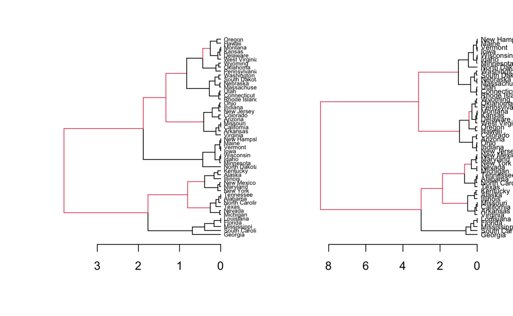

```r
dend_diff(clustering_dendrogram, alt_clustering_dendrogram)
```

How many clusters do we want / can we identify for our dataset?

[figure not shown]

```r
plot(clusters, cex = 0.6, hang = -1)
rect.hclust(clusters, k = 2, border = 2:5) # this marks the significant areas / clusters and can only be run with the plot code
# K = 2; number of clusters you want
```

[output not shown]

```r
plot(clusters, cex = 0.6, hang = -1)
rect.hclust(clusters, k = 4, border = 2:5)
```

[output not shown]

```r
edu_clustered_h2 <- edu_data %>%
  mutate(school_cluster = cutree(clusters, 2))
```

Carry out cluster analysis for other variables. What do you find for each variable? How many clusters do you choose, and why? What are your interpretations fromr your analysis?

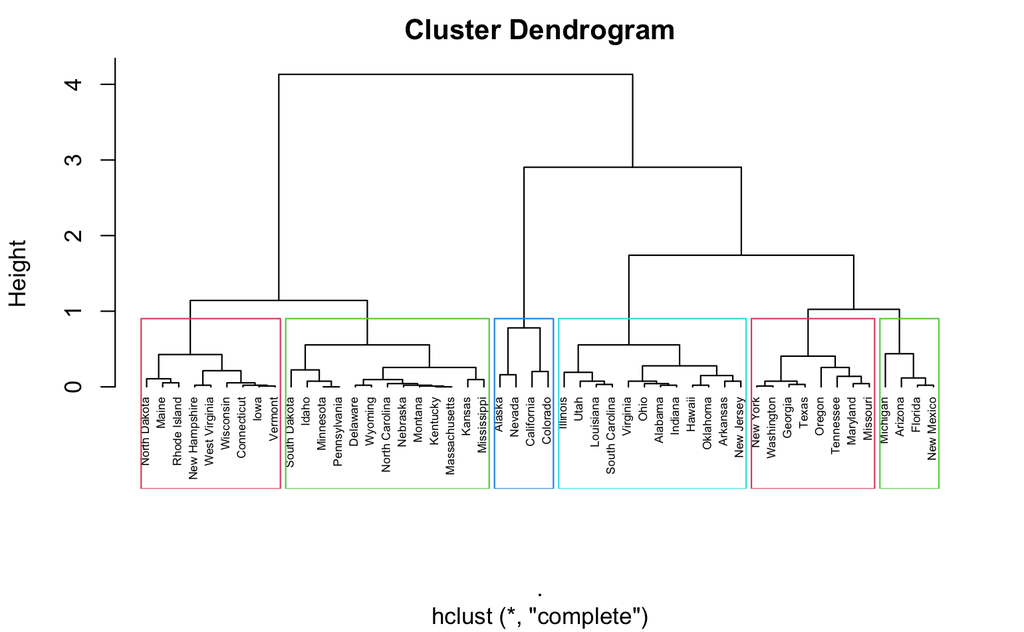

** LUNCH BREAK**

## K means clustering

You can tell it how many you’re looking for, and it will group into this many (centroids)

When running k-means, the centroids get randomly placed Then observations get assigned to a centroid, based on euclidean distance The centroid is then moved to the centre of the cluster

```r
edu_data <- read_csv("data/school_data.csv")
```

```r
library(janitor)
edu_data <- edu_data %>%
  column_to_rownames("X1") %>%
  clean_names()
```

```r
edu_data <- edu_data %>%
  select(home_school, state_school)
```

plotting the data, getting an overview of it

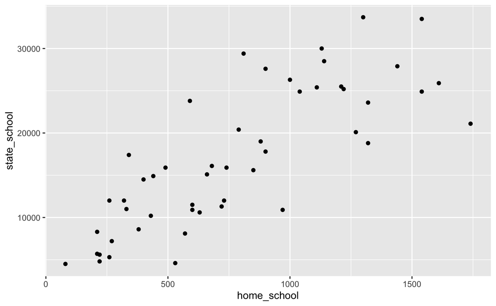

Scaling the data

```r
edu_scale <- edu_data %>%
  mutate_if(is.numeric, scale)
```

Doing the k-means clustering

```r
set.seed(1234)

# when doing this in practice, the seed shouldn't be set.

clustered_edu <- kmeans(edu_scale,
                        centers = 6,
                        nstart = 25)
clustered_edu
```

```
K-means clustering with 6 clusters of sizes 7, 10, 8, 8, 9, 8

Cluster means:
  home_school state_school
1 -0.20715961   -0.7582235
2  0.70531354    1.2688141
3 -0.92423166   -0.4305976
4  1.59269532    0.8878339
5 -1.18093078   -1.3210514
6 -0.04029379    0.1063745

Clustering vector:
       Alabama         Alaska        Arizona       Arkansas     California       Colorado    Connecticut       Delaware
             4              2              2              6              2              6              3              6
       Florida        Georgia         Hawaii          Idaho       Illinois        Indiana           Iowa         Kansas
             4              4              5              3              2              1              5              1
      Kentucky      Louisiana          Maine       Maryland  Massachusetts       Michigan      Minnesota    Mississippi
             1              4              5              2              3              2              5              4
      Missouri        Montana       Nebraska         Nevada  New Hampshire     New Jersey     New Mexico       New York
             6              1              3              2              5              6              2              2
North Carolina   North Dakota           Ohio       Oklahoma         Oregon   Pennsylvania   Rhode Island South Carolina
             2              5              1              6              3              1              3              4
  South Dakota      Tennessee          Texas           Utah        Vermont       Virginia     Washington  West Virginia
             5              4              4              3              5              6              3              1
     Wisconsin        Wyoming
             5              6

Within cluster sum of squares by cluster:
[1] 0.7436899 2.1018616 0.8700729 3.2796553 0.9594623 1.3691194
 (between_SS / total_SS =  90.5 %)

Available components:

[1] "cluster"      "centers"      "totss"        "withinss"     "tot.withinss" "betweenss"    "size"         "iter"
[9] "ifault"
```

| home_school | state_school | size | withinss | cluster |
| --- | --- | --- | --- | --- |
| -0.20715961 | -0.7582235 | 7 | 0.7436899 | 1 |
| 0.70531354 | 1.2688141 | 10 | 2.1018616 | 2 |
| -0.92423166 | -0.4305976 | 8 | 0.8700729 | 3 |
| 1.59269532 | 0.8878339 | 8 | 3.2796553 | 4 |
| -1.18093078 | -1.3210514 | 9 | 0.9594623 | 5 |
| -0.04029379 | 0.1063745 | 8 | 1.3691194 | 6 |

```r
clustered_edu$totss
```

```
[1] 98
```

```r
max_k <- 20

k_clusters <- tibble(k = 1:max_k) %>%
  mutate(
    kclust = map(k, ~ kmeans(edu_scale, .x, nstart = 25)),
    tidied = map(kclust, tidy),
    glanced = map(kclust, glance),
    augmented = map(kclust, augment, edu_data)
  )

k_clusters
```

| k | kclust | tidied | glanced | augmented |
| --- | --- | --- | --- | --- |
| 1 |  |  |  |  |
| 2 |  |  |  |  |
| 3 |  |  |  |  |
| 4 |  |  |  |  |
| 5 |  |  |  |  |
| 6 |  |  |  |  |
| 7 |  |  |  |  |
| 8 |  |  |  |  |
| 9 |  |  |  |  |
| 10 |  |  |  |  |

[output cut: 10 more lines]

How to access / read the data

```r
k_clusters %>%
  select(1,5) %>%
  unnest()
```

| k | .rownames | home_school | state_school | .cluster |
| --- | --- | --- | --- | --- |
| 1 | Alabama | 1320 | 23600 | 1 |
| 1 | Alaska | 1000 | 26300 | 1 |
| 1 | Arizona | 810 | 29400 | 1 |
| 1 | Arkansas | 880 | 19000 | 1 |
| 1 | California | 900 | 27600 | 1 |
| 1 | Colorado | 790 | 20400 | 1 |
| 1 | Connecticut | 330 | 11000 | 1 |
| 1 | Delaware | 590 | 23800 | 1 |
| 1 | Florida | 1540 | 33500 | 1 |
| 1 | Georgia | 1740 | 21100 | 1 |

[output cut: 990 more lines]

metric of interest: **tot.withinss**

optimal number of clusters

```r
# elbow method/point - is a way of choosing the number of clusters
```

[output not shown]

[output cut: 10 more lines]

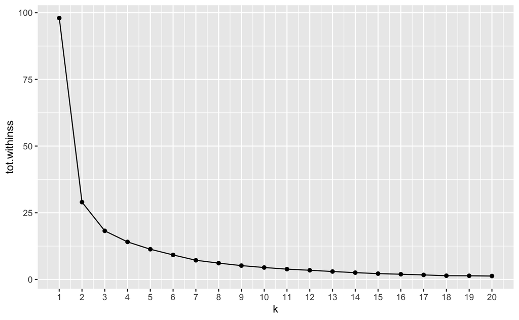

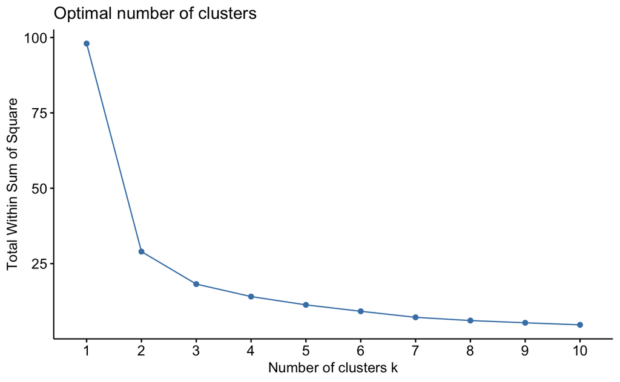

```r
library(factoextra)

fviz_nbclust(edu_scale,
             kmeans,
             method = "wss",
             nstart = 25)
```

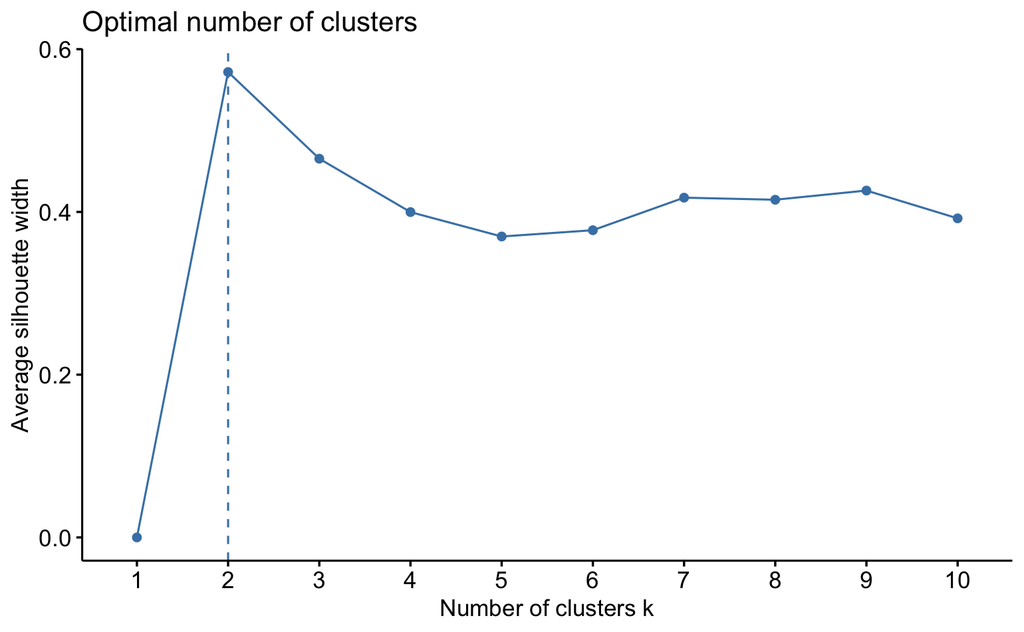

a different method of chosing the optimal number of clusters

```
Clustering k = 1,2,..., K.max (= 10): .. done
Bootstrapping, b = 1,2,..., B (= 100)  [one "." per sample]:
.................................................. 50
.................................................. 100
```

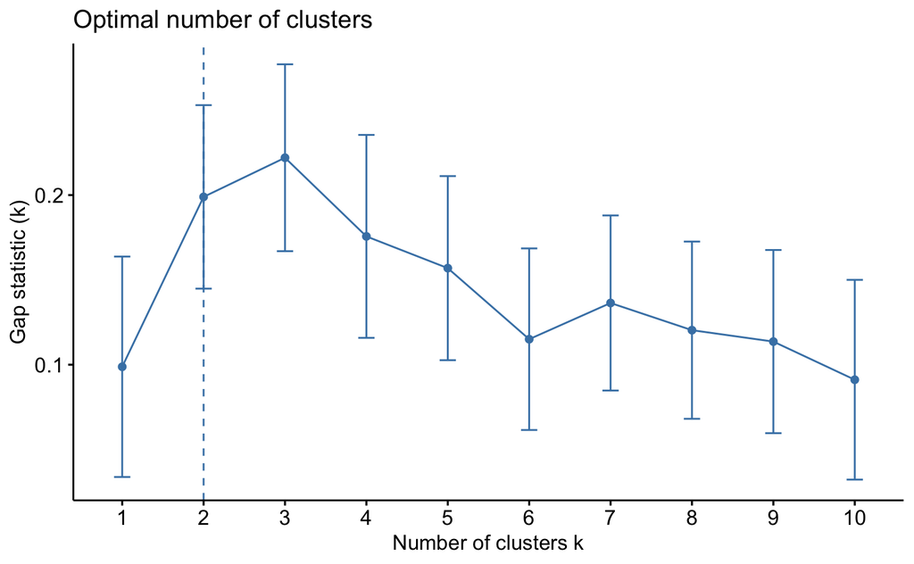

```r
fviz_nbclust(edu_scale,
             kmeans,
             method = "gap_stat",
             nstart = 25,
             k.max = 10)
```

visualising the chosen plot

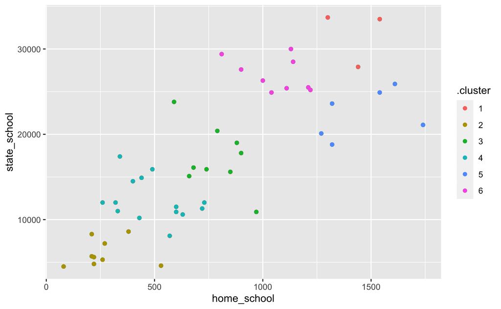

```r
clusterings %>%
  unnest(cols = c(augmented)) %>%
  filter(k <= 6) %>%
  ggplot(aes(x = home_school, y = state_school)) +
  geom_point(aes(color = .cluster))
```

plotting 2 clusters, with labels

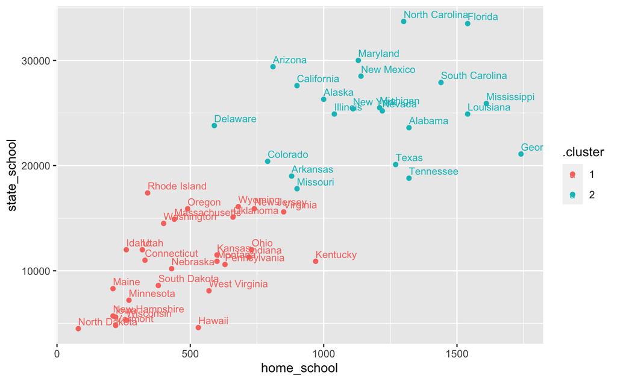

```r
clusterings %>%
  unnest(cols = c(augmented)) %>%
  filter(k == 2) %>%
 ggplot(aes(x = home_school, y = state_school, colour = .cluster, label = .rownames)) +
  geom_point(aes(color = .cluster)) +
  geom_text(hjust = 0, vjust = - 0.5, size = 3)
```